Colegio Universitario de Cartago

Presentación - Proyecto Final

Grupo E

**Integrantes:**  
Sharon Obando Gómez  
Fiorella Abarca Valverde  
Monica Mendoza Morales  
Roberto Montoya Leiva  
Roberto Coto Guevara

**Carrera: Big Data**

**Materia: BD-165 · Modelos Estadísticos Avanzados**

**Profesor: David Martínez Salazar**

14 de agosto de 2026

## Primera Técnica: Análisis de Clustering

```r
library(tidyverse)
library(lubridate)
library(DT)
library(corrplot)
```

### Introducción

#### Contexto

El análisis de segmentación de clientes es uno de los problemas clásicos de la minería de datos aplicada a negocios de retail. Comprender qué grupos de clientes existen dentro de una base transaccional permite diseñar estrategias diferenciadas de marketing, fidelización, precios y logística. Los métodos de clustering son la herramienta estadística central para descubrir esta estructura oculta, dado que no se dispone de etiquetas previas que indiquen a qué segmento pertenece cada cliente.

Para este trabajo se utiliza el conjunto de datos Sample Superstore, un dataset transaccional de una cadena de retail estadounidense entre 2014 y 2017, ampliamente usado con fines didácticos (Tableau / Kaggle). El dataset está registrado a nivel de línea de pedido, por lo que se requiere un trabajo de preparación antes de aplicar los algoritmos de clustering.

#### Objetivos

**Objetivo general**

Queremos usar diferentes formas de agrupar clientes, como el método particional, el método jerárquico y el método basado en densidad, para encontrar grupos de clientes que compren de manera similar. Vamos a hacer esto con la base de datos llamada Sample Superstore.

Aquí están los objetivos específicos:

1. Describir la estructura del dataset. Mostrar la calidad del dataset. Indicar las variables que se encuentran en el dataset.
2. Realizar una exploración de los datos. Preparar los datos para el análisis. Limpiar los datos. Identificar y tratar los valores atípicos. Resolver los datos que faltan. Realizar el escalado de las variables.
3. Usar los métodos de k-means. Usar el clustering jerárquico. Usar DBSCAN. Comparar los resultados obtenidos con cada uno de estos métodos.
4. Analizar los segmentos que se forman. Definir las características de cada segmento. Hacer recomendaciones basadas en los resultados obtenidos..0

#### Pregunta de análisis

> ¿Es posible identificar segmentos de clientes estadísticamente diferenciados y accionables a partir de su comportamiento de compra (recencia, frecuencia, monto, rentabilidad y descuentos), y qué tan consistentes son los resultados entre distintos métodos de clustering?

El conjunto de datos Sample Superstore es una base de transacciones de ejemplo de una tienda minorista en Estados Unidos. Se utiliza para enseñar y aprender, y se puede encontrar en Kaggle con el nombre “Sample Superstore”.

```r
df <- read.csv("Sample - Superstore.csv")
```

```r
nrow(df)
```

```
## [1] 9994
```

```r
ncol(df)
```

```
## [1] 21
```

```r
n_distinct(df$`Order ID`)
```

```
## [1] 0
```

```r
n_distinct(df$`Customer ID`)
```

```
## [1] 0
```

#### Variables

La base tiene 21 columnas. Las principales para este análisis son:

| Variable | Descripción |
| --- | --- |
| `Customer ID` | Identificador único del cliente (clave de agregación) |
| `Order ID` | Identificador de la orden de compra |
| `Order Date` | Fecha del pedido |
| `Sales` | Monto de venta (USD) |
| `Quantity` | Unidades vendidas |
| `Discount` | Proporción de descuento (0 a 1) |
| `Profit` | Ganancia (USD, puede ser negativa) |
| `Segment`, `Category`, `Region` | Variables descriptivas / categóricas |

```r
names(df)
```

```
##  [1] "Row.ID"        "Order.ID"      "Order.Date"    "Ship.Date"
##  [5] "Ship.Mode"     "Customer.ID"   "Customer.Name" "Segment"
##  [9] "Country"       "City"          "State"         "Postal.Code"
## [13] "Region"        "Product.ID"    "Category"      "Sub.Category"
## [17] "Product.Name"  "Sales"         "Quantity"      "Discount"
## [21] "Profit"
```

### Exploración y preparación de los datos

#### Estructura general

```r
str(df)
```

```
## 'data.frame':    9994 obs. of  21 variables:
##  $ Row.ID       : int  1 2 3 4 5 6 7 8 9 10 ...
##  $ Order.ID     : chr  "CA-2016-152156" "CA-2016-152156" "CA-2016-138688" "US-2015-108966" ...
##  $ Order.Date   : chr  "11/8/2016" "11/8/2016" "6/12/2016" "10/11/2015" ...
##  $ Ship.Date    : chr  "11/11/2016" "11/11/2016" "6/16/2016" "10/18/2015" ...
##  $ Ship.Mode    : chr  "Second Class" "Second Class" "Second Class" "Standard Class" ...
##  $ Customer.ID  : chr  "CG-12520" "CG-12520" "DV-13045" "SO-20335" ...
##  $ Customer.Name: chr  "Claire Gute" "Claire Gute" "Darrin Van Huff" "Sean O'Donnell" ...
##  $ Segment      : chr  "Consumer" "Consumer" "Corporate" "Consumer" ...
##  $ Country      : chr  "United States" "United States" "United States" "United States" ...
##  $ City         : chr  "Henderson" "Henderson" "Los Angeles" "Fort Lauderdale" ...
##  $ State        : chr  "Kentucky" "Kentucky" "California" "Florida" ...
##  $ Postal.Code  : int  42420 42420 90036 33311 33311 90032 90032 90032 90032 90032 ...
##  $ Region       : chr  "South" "South" "West" "South" ...
##  $ Product.ID   : chr  "FUR-BO-10001798" "FUR-CH-10000454" "OFF-LA-10000240" "FUR-TA-10000577" ...
##  $ Category     : chr  "Furniture" "Furniture" "Office Supplies" "Furniture" ...
##  $ Sub.Category : chr  "Bookcases" "Chairs" "Labels" "Tables" ...
##  $ Product.Name : chr  "Bush Somerset Collection Bookcase" "Hon Deluxe Fabric Upholstered Stacking Chairs, Rounded Back" "Self-Adhesive Address Labels for Typewriters by Universal" "Bretford CR4500 Series Slim Rectangular Table" ...
##  $ Sales        : num  262 731.9 14.6 957.6 22.4 ...
##  $ Quantity     : int  2 3 2 5 2 7 4 6 3 5 ...
##  $ Discount     : num  0 0 0 0.45 0.2 0 0 0.2 0.2 0 ...
##  $ Profit       : num  41.91 219.58 6.87 -383.03 2.52 ...
```

#### Valores faltantes

```r
colSums(is.na(df))
```

```
##        Row.ID      Order.ID    Order.Date     Ship.Date     Ship.Mode
##             0             0             0             0             0
##   Customer.ID Customer.Name       Segment       Country          City
##             0             0             0             0             0
##         State   Postal.Code        Region    Product.ID      Category
##             0             0             0             0             0
##  Sub.Category  Product.Name         Sales      Quantity      Discount
##             0             0             0             0             0
##        Profit
##             0
```

#### Filas duplicadas

```r
sum(duplicated(df))
```

```
## [1] 0
```

#### Corrección de tipos de datos

```r
df$Order.Date <- mdy(df$Order.Date)
df$Ship.Date  <- mdy(df$Ship.Date)

range(df$Order.Date)
```

```
## [1] "2014-01-03" "2017-12-30"
```

#### Revisión de rangos lógicos

```r
min(df$Sales)
```

```
## [1] 0.444
```

```r
max(df$Discount)
```

```
## [1] 0.8
```

```r
mean(df$Profit < 0) * 100
```

```
## [1] 18.72123
```

**18,7%** de las filas, lo cual es válido (pedidos con mucho descuento dan

pérdida) y se conserva como información relevante.

#### Construir variables por cliente (RFM)

El dataset está a nivel de línea de pedido. Para el clustering necesitamos **una fila por cliente**, con indicadores de comportamiento tipo RFM:

- **Recencia**: días desde la última compra.
- **Frecuencia**: cantidad de órdenes distintas.
- **Monto**: total gastado.
- **Ganancia**: utilidad total generada.
- **Descuento_prom**: descuento promedio recibido.

```r
fecha_ref <- max(df$Order.Date) + 1

clientes <- df %>%
  group_by(Customer.ID) %>%
  summarise(
    Recencia       = as.numeric(fecha_ref - max(Order.Date)),
    Frecuencia     = n_distinct(Order.ID),
    Monto          = sum(Sales),
    Ganancia       = sum(Profit),
    Descuento_prom = mean(Discount)
  )

dim(clientes)
```

```
## [1] 793   6
```

```r
head(clientes)
```

```
## # A tibble: 6 × 6
##   Customer.ID Recencia Frecuencia Monto Ganancia Descuento_prom
##   <chr>          <dbl>      <int> <dbl>    <dbl>          <dbl>
## 1 AA-10315         185          5 5564.    -363.         0.0909
## 2 AA-10375          20          9 1056.     277.         0.08
## 3 AA-10480         260          4 1791.     436.         0.0167
## 4 AA-10645          56          6 5087.     858.         0.0639
## 5 AB-10015         416          3  886.     129.         0.0667
## 6 AB-10060          55          8 7756.    2055.         0.0444
```

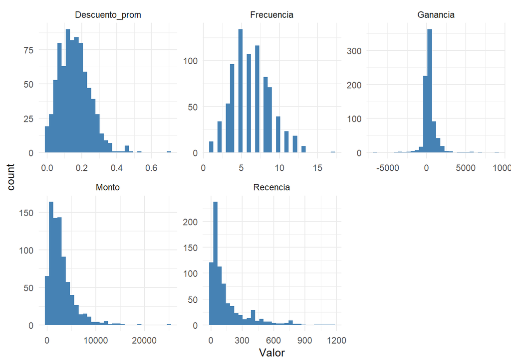

```r
clientes_largo <- pivot_longer(clientes, cols = Recencia:Descuento_prom,
                                names_to = "Variable", values_to = "Valor")

ggplot(clientes_largo, aes(x = Valor)) +
  geom_histogram(bins = 30, fill = "steelblue") +
  facet_wrap(~ Variable, scales = "free") +
  theme_minimal()
```

#### Outliers

```r
q1 <- quantile(clientes$Monto, 0.25)
q3 <- quantile(clientes$Monto, 0.75)
iqr <- q3 - q1
limite_sup <- q3 + 1.5 * iqr

sum(clientes$Monto > limite_sup)
```

```
## [1] 43
```

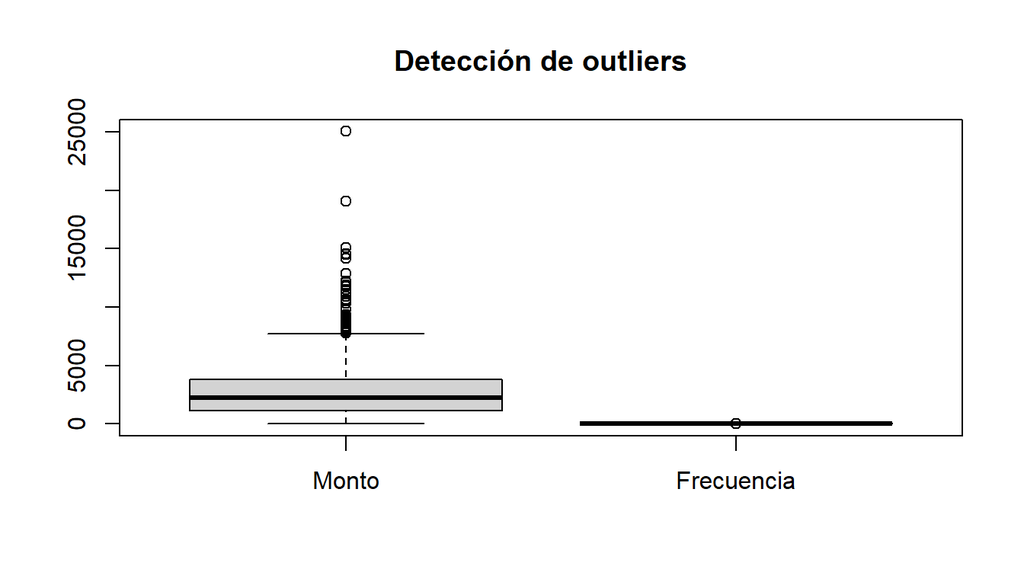

```r
boxplot(clientes$Monto, clientes$Frecuencia,
        names = c("Monto", "Frecuencia"),
        main = "Detección de outliers")
```

#### Correlaciones

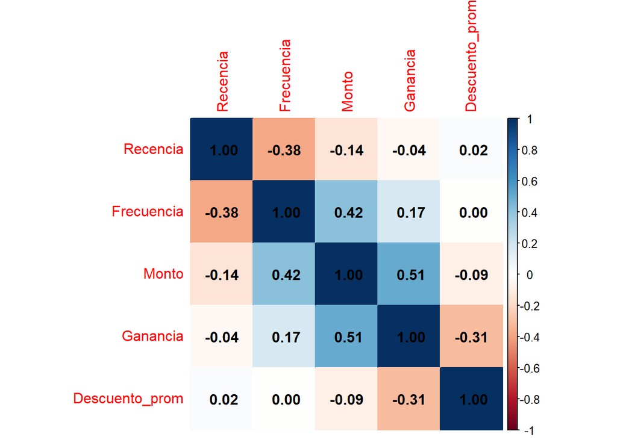

```r
matriz_cor <- cor(clientes[, -1])
corrplot(matriz_cor, method = "color", addCoef.col = "black")
```

#### Verificacion de faltantes final

```r
colSums(is.na(clientes))
```

```
##    Customer.ID       Recencia     Frecuencia          Monto       Ganancia
##              0              0              0              0              0
## Descuento_prom
##              0
```

#### Escalado de variables

```r
clientes_z <- clientes   # copia para agregar columnas escaladas

clientes_z$Recencia_z       <- as.numeric(scale(clientes$Recencia))
clientes_z$Frecuencia_z     <- as.numeric(scale(clientes$Frecuencia))
clientes_z$Monto_z          <- as.numeric(scale(clientes$Monto))
clientes_z$Ganancia_z       <- as.numeric(scale(clientes$Ganancia))
clientes_z$Descuento_prom_z <- as.numeric(scale(clientes$Descuento_prom))

head(clientes_z)
```

```
## # A tibble: 6 × 11
##   Customer.ID Recencia Frecuencia Monto Ganancia Descuento_prom Recencia_z
##   <chr>          <dbl>      <int> <dbl>    <dbl>          <dbl>      <dbl>
## 1 AA-10315         185          5 5564.    -363.         0.0909      0.200
## 2 AA-10375          20          9 1056.     277.         0.08       -0.686
## 3 AA-10480         260          4 1791.     436.         0.0167      0.603
## 4 AA-10645          56          6 5087.     858.         0.0639     -0.493
## 5 AB-10015         416          3  886.     129.         0.0667      1.44
## 6 AB-10060          55          8 7756.    2055.         0.0444     -0.498
## # ℹ 4 more variables: Frecuencia_z <dbl>, Monto_z <dbl>, Ganancia_z <dbl>,
## #   Descuento_prom_z <dbl>
```

```r
#write_csv(clientes_z, "C:\\Modelos Estadisticos avanzados\\Proyecto #Final\\clientes_preparado.csv")
```

### Modelado y Clustering

##### Aplicación del modelo K-Means

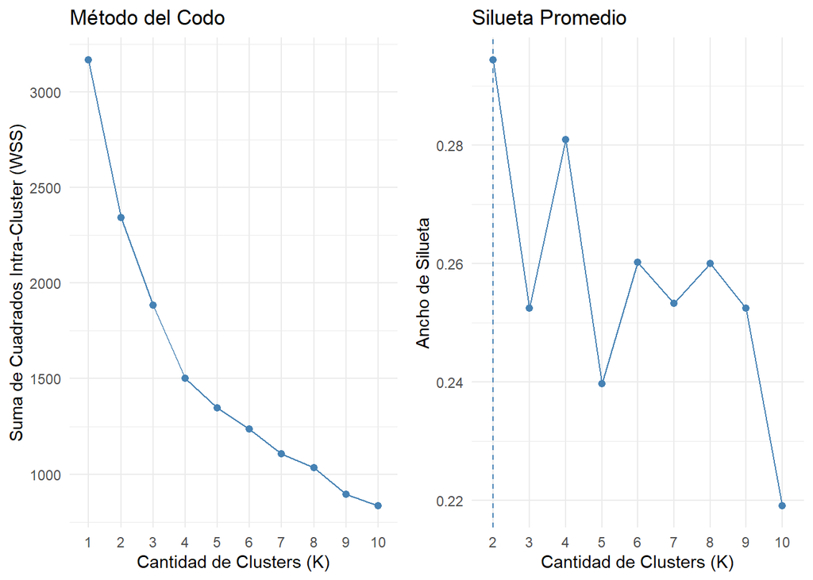

```r
library(tidyverse)
library(factoextra)

#Columnas que se utilizaran para el cluster
dat_cluster <- clientes_z %>%
  select(Frecuencia_z, Monto_z, Ganancia_z, Descuento_prom_z) %>%
  as.data.frame()

#Creación del método del codo
codo <- fviz_nbclust(dat_cluster, kmeans, method = "wss", k.max = 10) +
  labs(
    title = "Método del Codo",
    x = "Cantidad de Clusters (K)",
    y = "Suma de Cuadrados Intra-Cluster (WSS)"
  ) +
  theme_minimal()

#Creación de la silueta
silueta <- fviz_nbclust(dat_cluster, kmeans, method = "silhouette", k.max = 10) +
  labs(
    title = "Silueta Promedio",
    x = "Cantidad de Clusters (K)",
    y = "Ancho de Silueta"
  ) +
  theme_minimal()

gridExtra::grid.arrange(codo, silueta, ncol = 2)
```

Al analizar el **método del codo**, la disminución de **WSS** es marcada hasta K=4, después de esto la curva empieza a aplanarse.

En cuanto al **ancho de silueta**, el valor más alto lo obtenemos en K=2, pero este número de clusters es muy pequeño y resulta poco útil para efectos de segmentación, ya que agrupa a los clientes en categorías muy generales. Realizando un análisis más detallado, podemos notar que existe un pico en K=4 que coincide con el método del codo y es el segundo valor más alto del gráfico.

Tomando en consideración que ambos métodos coinciden en K=4, se selecciona este valor como el número de clusters a utilizar, ya que representa un balance adecuado entre compactación y separación de los grupos.

##### Selección del K y Ejecución del Modelo

```r
set.seed(123)

fit_kmeans <- kmeans(dat_cluster, centers = 4, nstart = 25)

# Se guarda el cluster en ambos df
clientes_z$Cluster_KM <- as.factor(fit_kmeans$cluster)
clientes$Cluster_KM   <- as.factor(fit_kmeans$cluster)

table(clientes_z$Cluster_KM)
```

```
##
##   1   2   3   4
##  59 204 267 263
```

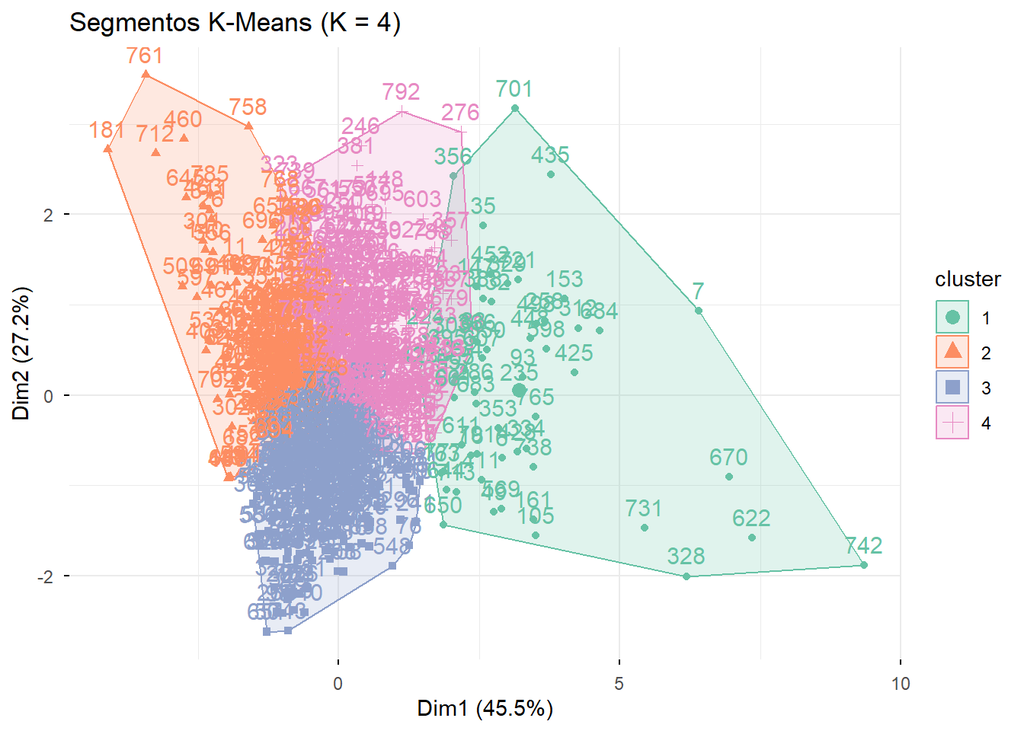

```r
fviz_cluster(
  fit_kmeans,
  data = dat_cluster,
  ellipse.type = "convex",
  palette = "Set2",
  ggtheme = theme_minimal(),
  main = "Segmentos K-Means (K = 4)"
)
```

```r
perfiles_km <- clientes %>%
  group_by(Cluster_KM) %>%
  summarise(
    Clientes        = n(),
    Frecuencia_prom = round(mean(Frecuencia), 1),
    Monto_prom      = round(mean(Monto), 2),
    Ganancia_prom   = round(mean(Ganancia), 2),
    Descuento_prom  = round(mean(Descuento_prom), 3)
  )

datatable(perfiles_km, options = list(dom = 't', ordering = FALSE),
          caption = "Promedios por Cluster")
```

|  | Cluster_KM | Clientes | Frecuencia_prom | Monto_prom | Ganancia_prom | Descuento_prom |
| --- | --- | --- | --- | --- | --- | --- |
| 1 | 1 | 59 | 8.3 | 9321.85 | 2229.42 | 0.116 |
| 2 | 2 | 204 | 4.7 | 1616.59 | -95.01 | 0.256 |
| 3 | 3 | 267 | 4.7 | 1797.63 | 327.06 | 0.087 |
| 4 | 4 | 263 | 8.7 | 3564.49 | 330.49 | 0.162 |

Con estos resultados podemos determinar lo siguiente:

**Cluster 1:** Solo hay 59 clientes, pero son los más valiosos, estos tienen una frecuencia de compra muy alta (8.3), el monto promedio de estos es el más alto (9321.85) y de mayor ganancia (2229.42) y con un descuento moderado (0.116). Estos serían categorizados como los clientes VIP.

**Cluster 2:** Este cluster contiene los clientes (204) con frecuencia más baja (4.7) junto con el cluster 3, el monto promedio es el más bajo (1616.59) y lo más importante a notar es la ganancia negativa (-95.01), a pesar de tener el descuento más alto (0.256). Lo que nos indica que estos clientes nos están generando pérdidas y posiblemente esto se deba al exceso de descuentos.

**Cluster 3:** El cluster más grande con 267 clientes, con una baja frecuencia (4.7) y un monto bajo (1797.63), pero marcando una diferencia con el Cluster 2 porque este grupo de clientes sí genera una ganancia positiva (327.06) y tiene el descuento más bajo (0.087). Son considerados clientes de bajo valor pero rentables.

**Cluster 4:** El segundo grupo más grande (263 clientes) combina alta frecuencia (8.7) con un monto promedio intermedio (3564.49) y ganancia similar al Cluster 3 (330.49) pero con un descuento más alto (0.162). Son catalogados como clientes frecuentes y razonablemente rentables.

#### Clustering Jerárquico

##### Matriz de Distancias y Dendrograma

Calculamos la matriz de distancias euclídeas sobre las variables escaladas y aplicamos el método de **Ward (Ward.D2)** para minimizar la varianza dentro de cada grupo.

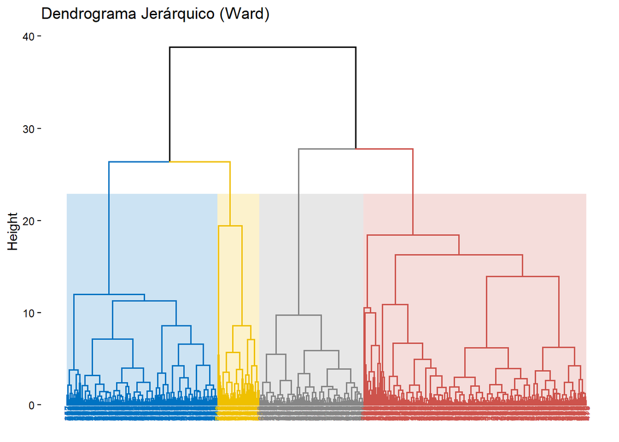

```r
library(cluster)

dist_matrix <- dist(dat_cluster, method = "euclidean")

# jerarquico con ward
fit_hc <- hclust(dist_matrix, method = "ward.D2")

fviz_dend(
  fit_hc,
  k = 4,
  cex = 0.5,
  k_colors = "jco",
  rect = TRUE,
  rect_fill = TRUE,
  rect_border = "jco",
  labels_track_height = 0.8,
  main = "Dendrograma Jerárquico (Ward)"
)
```

```r
# guardar los clusters
clientes_z$Cluster_HC <- as.factor(cutree(fit_hc, k = 4))
clientes$Cluster_HC   <- as.factor(cutree(fit_hc, k = 4))

table(clientes_z$Cluster_HC)
```

```
##
##   1   2   3   4
## 340 230 159  64
```

El dendrograma nos muestra una separación clara en 4 grupos principales, marcados con colores. La primera división ocurre a una altura cercana a 40, separando los primeros dos grupos. Los grupos azul y amarillo se separan a una altura menor (~25 aproximadamente), lo que sí indica que estos dos clusters son más parecidos entre sí que respecto a los otros dos.

##### Clustering basado en la densidad (DBSCAN)

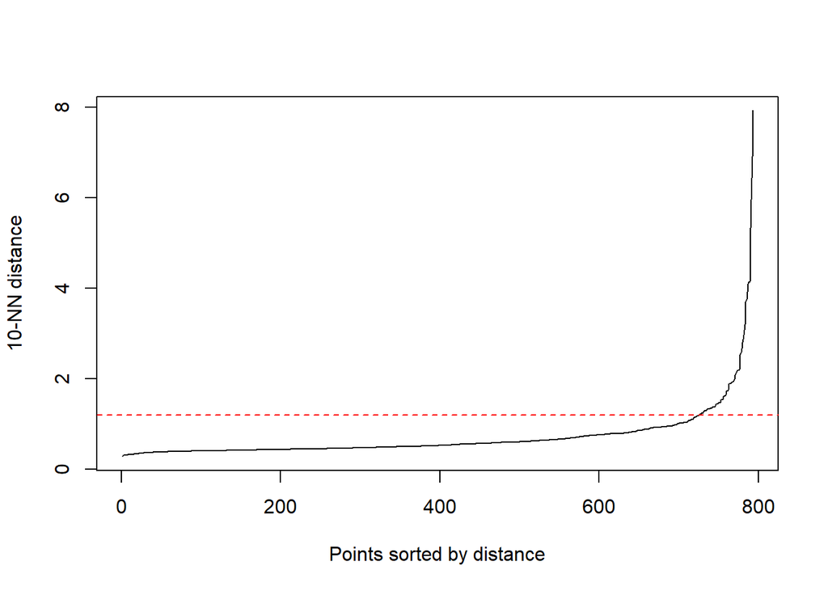

```r
#install.packages("dbscan")
library(dbscan)

# grafico k-NN para estimar eps
dbscan::kNNdistplot(dat_cluster, k = 10)
abline(h = 1.2, col = "red", lty = 2)
```

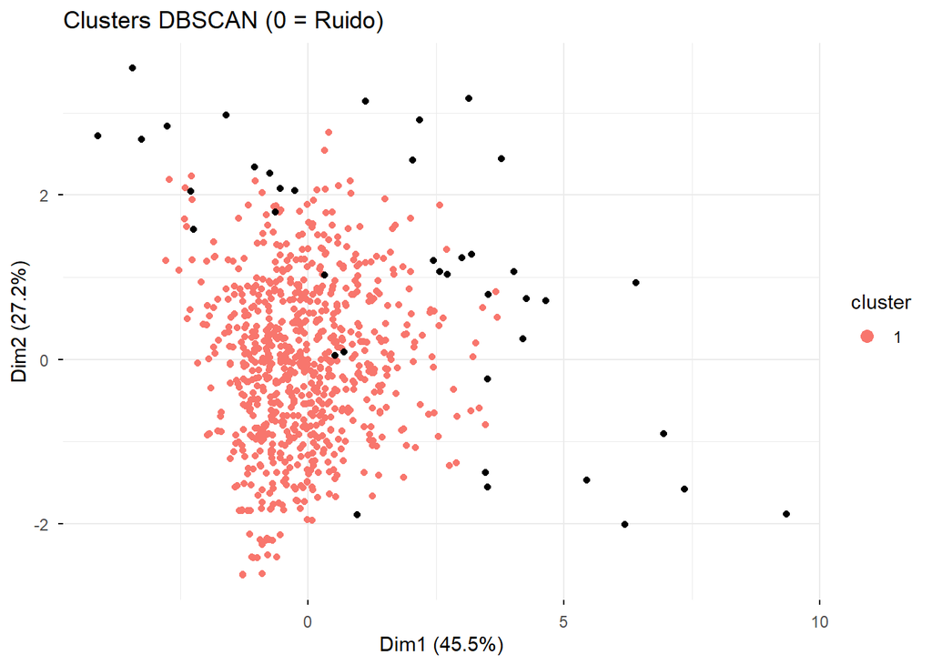

```r
set.seed(123)
fit_dbscan <- dbscan(dat_cluster, eps = 1.2, minPts = 10)

clientes_z$Cluster_DBS <- as.factor(fit_dbscan$cluster)
clientes$Cluster_DBS   <- as.factor(fit_dbscan$cluster)

# table(clientes_z$Cluster_DBS)  # 0 = ruido/outliers

fviz_cluster(
  fit_dbscan,
  data = dat_cluster,
  geom = "point",
  ellipse = FALSE,
  ggtheme = theme_minimal(),
  main = "Clusters DBSCAN (0 = Ruido)"
)
```

El gráfico de K-NN muestra que el punto del codo está aproximadamente en una distancia de 1.2, justo donde la curva empieza a crecer de forma pronunciada alrededor de los 750 puntos ordenados. Este valor fue el usado como **eps** para el modelo.

Aún así, al aplicar DBSCAN con eps = 1.2 y minPts = 10, el algoritmo identifica un único cluster (Cluster 1), agrupando a la mayoría de los clientes en una sola región densa. Los puntos marcados como ruido (Cluster 0, en negro) corresponden a los clientes más alejados o atípicos, principalmente ubicados en los extremos del gráfico.

Esto sugiere que la base de clientes no presenta regiones de densidad suficientemente distintas entre sí como para que DBSCAN las separe en múltiples grupos, a diferencia de los métodos de K-Means y clustering jerárquico, los cuales sí lograron segmentar a los clientes en 4 grupos diferenciados. En este caso, DBSCAN resulta más útil para identificar clientes atípicos (outliers) que para fines de segmentación general.

#### Comparación de los métodos de Clustering

```r
library(fpc)

sil_km <- silhouette(fit_kmeans$cluster, dist_matrix)
sil_hc <- silhouette(cutree(fit_hc, k = 4), dist_matrix)

# para dbscan excluyo el ruido del promedio
sil_db_val <- ifelse(
  length(unique(fit_dbscan$cluster[fit_dbscan$cluster != 0])) > 1,
  mean(silhouette(fit_dbscan$cluster, dist_matrix)[, 3]),
  NA
)

comparativa <- data.frame(
  Algoritmo = c("K-Means (K=4)", "Jerárquico (K=4)", "DBSCAN (eps=1.2)"),
  Clusters_Detectados = c(
    length(unique(fit_kmeans$cluster)),
    length(unique(cutree(fit_hc, k = 4))),
    length(unique(fit_dbscan$cluster[fit_dbscan$cluster != 0]))
  ),
  Puntos_Ruido = c(
    0,
    0,
    sum(fit_dbscan$cluster == 0)
  ),
  Silueta_Promedio = c(
    round(mean(sil_km[, 3]), 3),
    round(mean(sil_hc[, 3]), 3),
    round(sil_db_val, 3)
  )
)

datatable(comparativa, options = list(dom = 't', ordering = FALSE),
          caption = "Comparativa de Métodos de Clustering")
```

|  | Algoritmo | Clusters_Detectados | Puntos_Ruido | Silueta_Promedio |
| --- | --- | --- | --- | --- |
| 1 | K-Means (K=4) | 4 | 0 | 0.281 |
| 2 | Jerárquico (K=4) | 4 | 0 | 0.208 |
| 3 | DBSCAN (eps=1.2) | 1 | 40 |  |

La tabla comparativa nos confirma lo observado en los gráficos individuales. K-Means obtiene la silueta promedio más alta (0.281), seguido del método jerárquico (0.208), ambos logrando separar a los clientes en los 4 grupos esperados sin dejar puntos como ruido.

DBSCAN, en cambio, solo detectó 1 cluster real y clasificó a 40 clientes como outliers, por lo que su silueta promedio no aplica en este caso, ya que esta métrica requiere al menos 2 clusters para poder calcularse.

Con base en estos resultados, K-Means es el método más adecuado para la segmentación de clientes en este análisis, al presentar la mejor separación entre grupos y una estructura de 4 clusters consistente con lo visto antes en el método del codo y la silueta. El clustering jerárquico queda como alternativa de respaldo, mientras que DBSCAN se descarta para fines de segmentación, aunque podría servir más adelante para identificar clientes atípicos.

#### Conclusiones

##### Respuesta a la pregunta de análisis

> **¿Es posible identificar segmentos de clientes estadísticamente diferenciados y accionables a partir de su comportamiento de compra, y qué tan consistentes son los resultados entre distintos métodos de clustering?**

**Sí, es plenamente posible.** A partir de la transformación y agregación de la base transaccional a nivel de cliente con un enfoque RFM ampliado (*Frecuencia, Monto, Ganancia y Descuento promedio*), se identificaron cuatro segmentos de clientes estadísticamente bien diferenciados y directamente interpretables desde la perspectiva de negocio.

##### Comparativa y consistencia entre métodos de clustering

El método K-Means con K= 4 resultó ser el modelo con mejor desempeño general. Este modelo alcanzó el coeficiente de silueta promedio más alto, que fue de 0,281. La elección de K igual a 4 se basó en la combinación del Método del Codo y el análisis del Ancho de Silueta, que mostraron una caída en el WSS y el segundo pico más alto respectivamente.

El Clustering Jerárquico utilizando Ward.D2 con K= a 4 se utilizó como método de validación. Este método presentó una estructura jerárquica muy consistente con K-Means, alcanzando un ancho de silueta de 0,208. El dendrograma confirmó la separación natural de la base en 4 grandes familias de clientes.

El método DBSCAN con eps= a 1,2 y minPts igual a 10 se utilizó para la detección de outliers. Sin embargo, no resultó adecuado para segmentar comercialmente a la población, ya que agrupó a casi todos los clientes en una única región densa. Sin embargo, este método identificó 40 clientes atípicos, lo que complementa el análisis de outliers detectado previamente en la fase exploratoria, en el que se identificaron 43 clientes atípicos en cuanto al monto.

## Segunda Técnica: Regresión

A continuación se presenta el código de regresión tal como fue elaborado, organizado en bloques para facilitar la lectura en este documento.

**Nota (agregada solo para que el documento compile en HTML, sin tocar el código de regresión en sí):** el script original de regresión asume que ya existe un objeto `datos` con columnas en minúscula (`profit`, `sales`, `quantity`, `discount`, `ship_days`) y tres funciones de apoyo (`titulo()`, `subtitulo()`, `ok()`) que no estaban incluidas en el archivo `.R`. Se agregan aquí de forma mínima para que el resto del script corra sin modificaciones; si ya cuentan con su propia versión de estas piezas, pueden reemplazar este bloque por la suya.

```r
# --- Bloque agregado (no forma parte del script original de regresion.R) ---
# library(knitr) agregado aqui porque kable() se usa en el script pero
# la libreria no estaba siendo cargada explicitamente.
library(knitr)
datos <- Sample_Superstore %>%
  rename(
    profit   = Profit,
    sales    = Sales,
    quantity = Quantity,
    discount = Discount
  ) %>%
  mutate(
    Order.Date = as.Date(Order.Date, format = "%m/%d/%Y"),
    Ship.Date  = as.Date(Ship.Date, format = "%m/%d/%Y"),
    ship_days  = as.numeric(Ship.Date - Order.Date)
  )

titulo <- function(x) cat("\n\n---\n\n##", x, "\n\n")
subtitulo <- function(x) cat("\n\n###", x, "\n\n")
ok <- function(x) cat("\n✅", x, "\n")
```

```r
library(tidyverse)
library(GGally)
library(car)
library(jtools)
library(gvlma)
library(sandwich)
library(lmtest)
```

### Análisis De Regresión

```r
titulo("11. ANÁLISIS DE REGRESIÓN")
```

```
##
##
## ---
##
## ## 11. ANÁLISIS DE REGRESIÓN
```

### Preparación De Los Datos

```r
subtitulo("Preparación de datos para regresión")
```

```
##
##
## ### Preparación de datos para regresión
```

```r
datos_regresion <- datos %>%
  select(profit, sales, quantity, discount, ship_days) %>%
  drop_na()

cat("Observaciones utilizadas: ",
    format(nrow(datos_regresion), big.mark = ","), "\n", sep = "")
```

```
## Observaciones utilizadas: 9,994
```

```r
cat("Variables utilizadas: ",
    paste(names(datos_regresion), collapse = ", "), "\n", sep = "")
```

```
## Variables utilizadas: profit, sales, quantity, discount, ship_days
```

```r
ok("Datos preparados para el análisis")
```

```
##
## ✅ Datos preparados para el análisis
```

### Exploración Y Correlaciones

```r
subtitulo("Estructura de los datos")
```

```
##
##
## ### Estructura de los datos
```

```r
str(datos_regresion)
```

```
## 'data.frame':    9994 obs. of  5 variables:
##  $ profit   : num  41.91 219.58 6.87 -383.03 2.52 ...
##  $ sales    : num  262 731.9 14.6 957.6 22.4 ...
##  $ quantity : int  2 3 2 5 2 7 4 6 3 5 ...
##  $ discount : num  0 0 0 0.45 0.2 0 0 0.2 0.2 0 ...
##  $ ship_days: num  3 3 4 7 7 5 5 5 5 5 ...
```

```r
subtitulo("Resumen estadístico")
```

```
##
##
## ### Resumen estadístico
```

```r
print(summary(datos_regresion))
```

```
##      profit              sales              quantity        discount
##  Min.   :-6599.978   Min.   :    0.444   Min.   : 1.00   Min.   :0.0000
##  1st Qu.:    1.729   1st Qu.:   17.280   1st Qu.: 2.00   1st Qu.:0.0000
##  Median :    8.666   Median :   54.490   Median : 3.00   Median :0.2000
##  Mean   :   28.657   Mean   :  229.858   Mean   : 3.79   Mean   :0.1562
##  3rd Qu.:   29.364   3rd Qu.:  209.940   3rd Qu.: 5.00   3rd Qu.:0.2000
##  Max.   : 8399.976   Max.   :22638.480   Max.   :14.00   Max.   :0.8000
##    ship_days
##  Min.   :0.000
##  1st Qu.:3.000
##  Median :4.000
##  Mean   :3.958
##  3rd Qu.:5.000
##  Max.   :7.000
```

```r
subtitulo("Matriz de correlaciones")
```

```
##
##
## ### Matriz de correlaciones
```

```r
matriz_cor <- round(cor(datos_regresion), 3)

print(
  kable(
    matriz_cor
  )
)
```

```
##
##
## |          | profit|  sales| quantity| discount| ship_days|
## |:---------|------:|------:|--------:|--------:|---------:|
## |profit    |  1.000|  0.479|    0.066|   -0.219|    -0.005|
## |sales     |  0.479|  1.000|    0.201|   -0.028|    -0.007|
## |quantity  |  0.066|  0.201|    1.000|    0.009|     0.018|
## |discount  | -0.219| -0.028|    0.009|    1.000|     0.000|
## |ship_days | -0.005| -0.007|    0.018|    0.000|     1.000|
```

```r
subtitulo("Relaciones entre variables")
```

```
##
##
## ### Relaciones entre variables
```

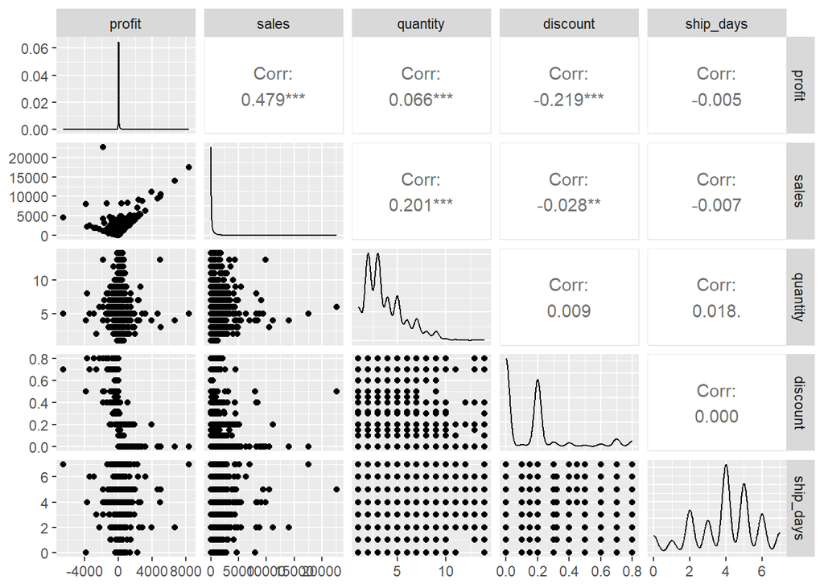

```r
ggpairs(datos_regresion)
```

### Modelo Completo

```r
titulo("11.3 MODELO DE REGRESIÓN COMPLETO")
```

```
##
##
## ---
##
## ## 11.3 MODELO DE REGRESIÓN COMPLETO
```

```r
modelo_completo <- lm(
  profit ~ sales + quantity + discount + ship_days,
  data = datos_regresion
)

subtitulo("Resumen del modelo completo")
```

```
##
##
## ### Resumen del modelo completo
```

```r
print(summary(modelo_completo))
```

```
##
## Call:
## lm(formula = profit ~ sales + quantity + discount + ship_days,
##     data = datos_regresion)
##
## Residuals:
##     Min      1Q  Median      3Q     Max
## -7266.5   -23.8    -0.4    25.6  5229.9
##
## Coefficients:
##               Estimate Std. Error t value Pr(>|t|)
## (Intercept)  3.525e+01  6.144e+00   5.737  9.9e-09 ***
## sales        1.800e-01  3.276e-03  54.954  < 2e-16 ***
## quantity    -2.961e+00  9.173e-01  -3.228  0.00125 **
## discount    -2.335e+02  9.687e+00 -24.100  < 2e-16 ***
## ship_days   -7.091e-02  1.144e+00  -0.062  0.95058
## ---
## Signif. codes:  0 '***' 0.001 '**' 0.01 '*' 0.05 '.' 0.1 ' ' 1
##
## Residual standard error: 199.8 on 9989 degrees of freedom
## Multiple R-squared:  0.2727, Adjusted R-squared:  0.2724
## F-statistic: 936.5 on 4 and 9989 DF,  p-value: < 2.2e-16
```

### Multicolinealidad

```r
subtitulo("Evaluación de multicolinealidad - VIF")
```

```
##
##
## ### Evaluación de multicolinealidad - VIF
```

```r
vif_resultado <- vif(modelo_completo)

print(
  round(vif_resultado, 3)
)
```

```
##     sales  quantity  discount ship_days
##     1.043     1.043     1.001     1.000
```

### Selección Del Modelo Final

```r
titulo("11.5 SELECCIÓN DEL MODELO")
```

```
##
##
## ---
##
## ## 11.5 SELECCIÓN DEL MODELO
```

```r
modelo_final <- step(
  modelo_completo,
  direction = "backward"
)
```

```
## Start:  AIC=105889.6
## profit ~ sales + quantity + discount + ship_days
##
##             Df Sum of Sq       RSS    AIC
## - ship_days  1       153 398833249 105888
## <none>                   398833096 105890
## - quantity   1    416046 399249142 105898
## - discount   1  23190509 422023605 106452
## - sales      1 120576662 519409758 108527
##
## Step:  AIC=105887.6
## profit ~ sales + quantity + discount
##
##            Df Sum of Sq       RSS    AIC
## <none>                  398833249 105888
## - quantity  1    416539 399249788 105896
## - discount  1  23190498 422023747 106450
## - sales     1 120595004 519428254 108526
```

```r
subtitulo("Resumen del modelo final")
```

```
##
##
## ### Resumen del modelo final
```

```r
print(summary(modelo_final))
```

```
##
## Call:
## lm(formula = profit ~ sales + quantity + discount, data = datos_regresion)
##
## Residuals:
##     Min      1Q  Median      3Q     Max
## -7266.8   -23.8    -0.4    25.6  5229.6
##
## Coefficients:
##               Estimate Std. Error t value Pr(>|t|)
## (Intercept)  3.497e+01  4.218e+00   8.291  < 2e-16 ***
## sales        1.800e-01  3.275e-03  54.961  < 2e-16 ***
## quantity    -2.962e+00  9.171e-01  -3.230  0.00124 **
## discount    -2.335e+02  9.686e+00 -24.101  < 2e-16 ***
## ---
## Signif. codes:  0 '***' 0.001 '**' 0.01 '*' 0.05 '.' 0.1 ' ' 1
##
## Residual standard error: 199.8 on 9990 degrees of freedom
## Multiple R-squared:  0.2727, Adjusted R-squared:  0.2725
## F-statistic:  1249 on 3 and 9990 DF,  p-value: < 2.2e-16
```

### Modelo Con Interacción

```r
subtitulo("Modelo con interacción Sales × Discount")
```

```
##
##
## ### Modelo con interacción Sales × Discount
```

```r
modelo_interaccion <- lm(
  profit ~ sales * discount + quantity,
  data = datos_regresion
)

print(summary(modelo_interaccion))
```

```
##
## Call:
## lm(formula = profit ~ sales * discount + quantity, data = datos_regresion)
##
## Residuals:
##     Min      1Q  Median      3Q     Max
## -4364.9    -3.0    10.5    25.8  3616.5
##
## Coefficients:
##                  Estimate Std. Error  t value Pr(>|t|)
## (Intercept)      6.993585   2.637463    2.652  0.00802 **
## sales            0.382699   0.002603  147.049  < 2e-16 ***
## discount       -41.910178   6.225110   -6.732 1.76e-11 ***
## quantity        -5.199278   0.571642   -9.095  < 2e-16 ***
## sales:discount  -1.240912   0.009889 -125.485  < 2e-16 ***
## ---
## Signif. codes:  0 '***' 0.001 '**' 0.01 '*' 0.05 '.' 0.1 ' ' 1
##
## Residual standard error: 124.5 on 9989 degrees of freedom
## Multiple R-squared:  0.7177, Adjusted R-squared:  0.7176
## F-statistic:  6349 on 4 and 9989 DF,  p-value: < 2.2e-16
```

### Comparación De Modelos

```r
titulo("11.7 COMPARACIÓN DE MODELOS")
```

```
##
##
## ---
##
## ## 11.7 COMPARACIÓN DE MODELOS
```

```r
cat("Modelos evaluados:\n")
```

```
## Modelos evaluados:
```

```r
cat("  • Modelo completo\n")
```

```
##   • Modelo completo
```

```r
cat("  • Modelo final\n")
```

```
##   • Modelo final
```

```r
cat("  • Modelo con interacción\n\n")
```

```
##   • Modelo con interacción
```

```r
subtitulo("AIC")
```

```
##
##
## ### AIC
```

```r
aic_modelos <- AIC(
  modelo_completo,
  modelo_final,
  modelo_interaccion
)

print(
  kable(
    aic_modelos,
    digits = 2,
    col.names = c(
      "Modelo",
      "Grados de libertad",
      "AIC"
    )
  )
)
```

```
##
##
## |Modelo             | Grados de libertad|      AIC|
## |:------------------|------------------:|--------:|
## |modelo_completo    |                  6| 134253.3|
## |modelo_final       |                  5| 134251.3|
## |modelo_interaccion |                  6| 124795.1|
```

```r
subtitulo("BIC")
```

```
##
##
## ### BIC
```

```r
bic_modelos <- BIC(
  modelo_completo,
  modelo_final,
  modelo_interaccion
)

print(
  kable(
    bic_modelos,
    digits = 2,
    col.names = c(
      "Modelo",
      "Grados de libertad",
      "BIC"
    )
  )
)
```

```
##
##
## |Modelo             | Grados de libertad|      BIC|
## |:------------------|------------------:|--------:|
## |modelo_completo    |                  6| 134296.6|
## |modelo_final       |                  5| 134287.4|
## |modelo_interaccion |                  6| 124838.4|
```

```r
subtitulo("Comparación visual de coeficientes")
```

```
##
##
## ### Comparación visual de coeficientes
```

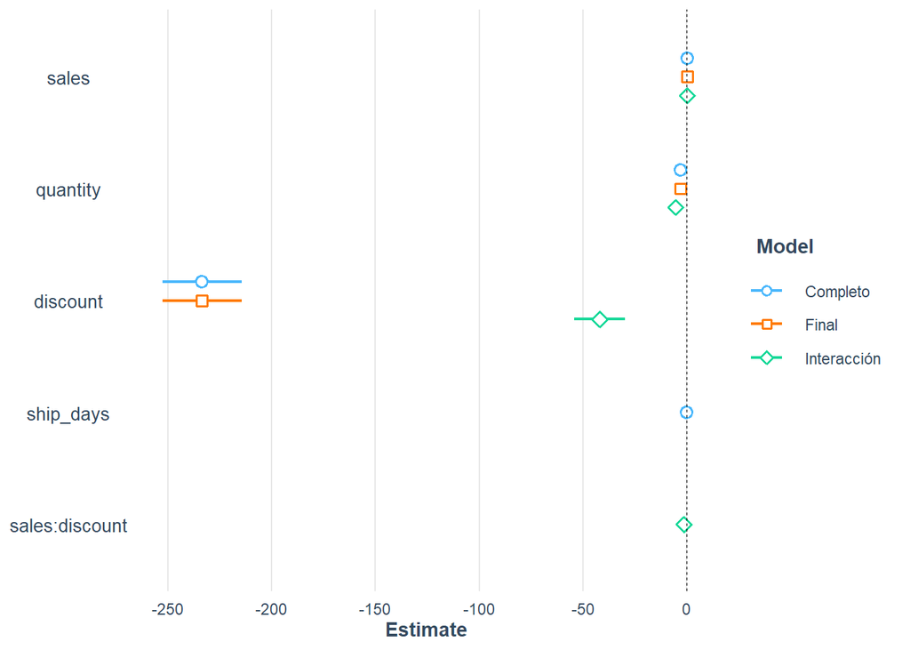

```r
plot_summs(
  modelo_completo,
  modelo_final,
  modelo_interaccion,
  model.names = c(
    "Completo",
    "Final",
    "Interacción"
  )
)
```

### Evaluación Del Modelo

```r
titulo("11.8 EVALUACIÓN DEL MODELO")
```

```
##
##
## ---
##
## ## 11.8 EVALUACIÓN DEL MODELO
```

```r
subtitulo("Diagnóstico GVLMA")
```

```
##
##
## ### Diagnóstico GVLMA
```

```r
print(
  summary(gvlma(modelo_interaccion))
)
```

```
##
## Call:
## lm(formula = profit ~ sales * discount + quantity, data = datos_regresion)
##
## Residuals:
##     Min      1Q  Median      3Q     Max
## -4364.9    -3.0    10.5    25.8  3616.5
##
## Coefficients:
##                  Estimate Std. Error  t value Pr(>|t|)
## (Intercept)      6.993585   2.637463    2.652  0.00802 **
## sales            0.382699   0.002603  147.049  < 2e-16 ***
## discount       -41.910178   6.225110   -6.732 1.76e-11 ***
## quantity        -5.199278   0.571642   -9.095  < 2e-16 ***
## sales:discount  -1.240912   0.009889 -125.485  < 2e-16 ***
## ---
## Signif. codes:  0 '***' 0.001 '**' 0.01 '*' 0.05 '.' 0.1 ' ' 1
##
## Residual standard error: 124.5 on 9989 degrees of freedom
## Multiple R-squared:  0.7177, Adjusted R-squared:  0.7176
## F-statistic:  6349 on 4 and 9989 DF,  p-value: < 2.2e-16
##
##
## ASSESSMENT OF THE LINEAR MODEL ASSUMPTIONS
## USING THE GLOBAL TEST ON 4 DEGREES-OF-FREEDOM:
## Level of Significance =  0.05
##
## Call:
##  gvlma(x = modelo_interaccion)
##
##                        Value p-value                   Decision
## Global Stat        4.523e+07  0.0000 Assumptions NOT satisfied!
## Skewness           3.623e+04  0.0000 Assumptions NOT satisfied!
## Kurtosis           4.520e+07  0.0000 Assumptions NOT satisfied!
## Link Function      7.215e+02  0.0000 Assumptions NOT satisfied!
## Heteroscedasticity 4.761e+00  0.0291 Assumptions NOT satisfied!
##                           Value    p-value                   Decision
## Global Stat        4.523383e+07 0.00000000 Assumptions NOT satisfied!
## Skewness           3.623329e+04 0.00000000 Assumptions NOT satisfied!
## Kurtosis           4.519687e+07 0.00000000 Assumptions NOT satisfied!
## Link Function      7.215478e+02 0.00000000 Assumptions NOT satisfied!
## Heteroscedasticity 4.761473e+00 0.02910364 Assumptions NOT satisfied!
```

### Gráficos De Diagnóstico

```r
subtitulo("Gráficos de diagnóstico")
```

```
##
##
## ### Gráficos de diagnóstico
```

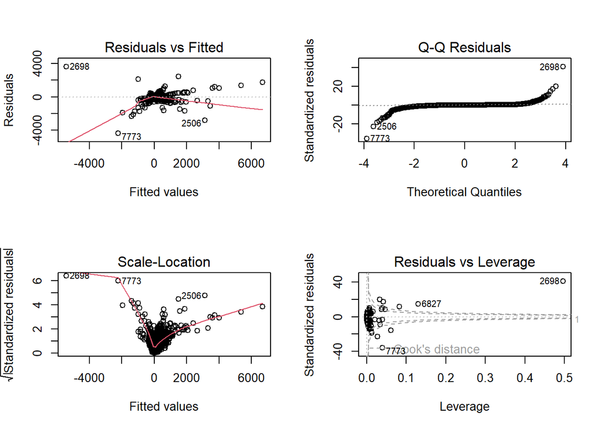

```r
par(mfrow = c(2, 2))

plot(modelo_interaccion)
```

```r
par(mfrow = c(1, 1))
```

### Residuos Contra Valores Ajustados

```r
subtitulo("Residuos contra valores ajustados")
```

```
##
##
## ### Residuos contra valores ajustados
```

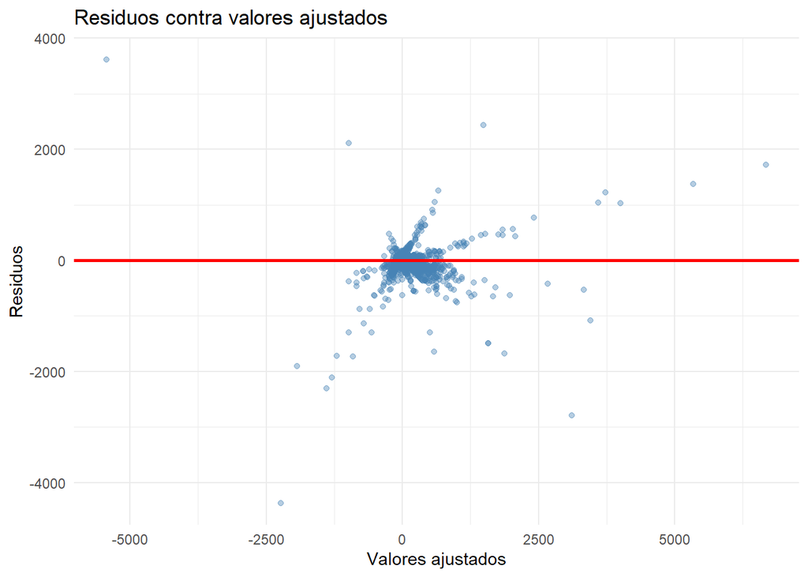

```r
datos_residuos <- data.frame(
  ajustados = fitted(modelo_interaccion),
  residuos = residuals(modelo_interaccion)
)

ggplot(
  datos_residuos,
  aes(x = ajustados, y = residuos)
) +
  geom_point(
    alpha = 0.4,
    color = "steelblue"
  ) +
  geom_hline(
    yintercept = 0,
    color = "red",
    linewidth = 1
  ) +
  labs(
    title = "Residuos contra valores ajustados",
    x = "Valores ajustados",
    y = "Residuos"
  ) +
  theme_minimal()
```

### Distribución De Los Residuos

```r
subtitulo("Distribución de los residuos")
```

```
##
##
## ### Distribución de los residuos
```

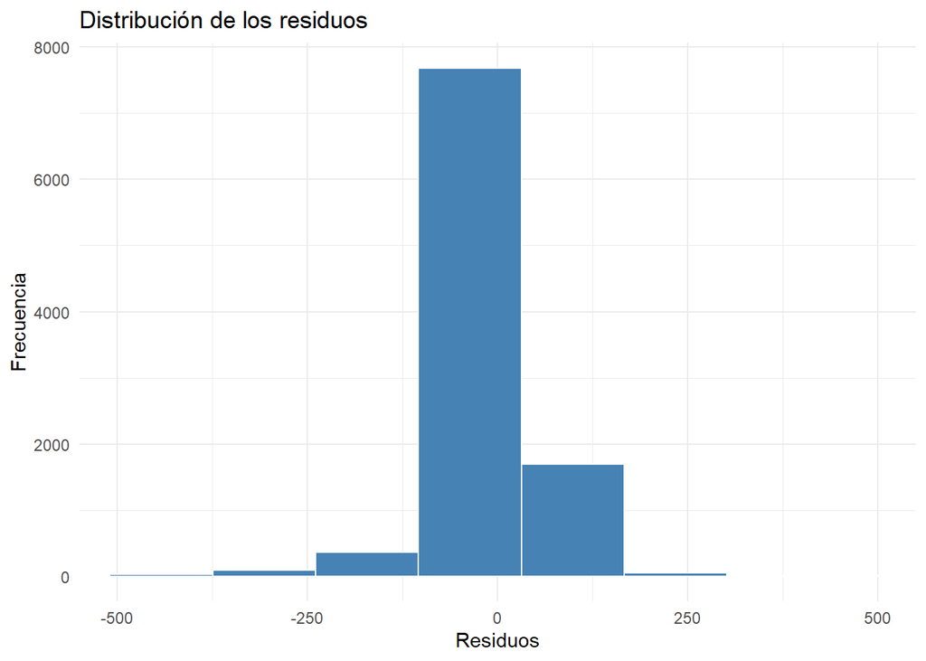

```r
ggplot(
  data.frame(
    residuos = residuals(modelo_interaccion)
  ),
  aes(x = residuos)
) +
  geom_histogram(
    bins = 60,
    fill = "steelblue",
    color = "white"
  ) +
  coord_cartesian(
    xlim = c(-500, 500)
  ) +
  labs(
    title = "Distribución de los residuos",
    x = "Residuos",
    y = "Frecuencia"
  ) +
  theme_minimal()
```

### Errores Estándar Robustos

```r
titulo("11.12 ERRORES ESTÁNDAR ROBUSTOS")
```

```
##
##
## ---
##
## ## 11.12 ERRORES ESTÁNDAR ROBUSTOS
```

```r
subtitulo("Prueba con errores robustos HC3")
```

```
##
##
## ### Prueba con errores robustos HC3
```

```r
resultado_hc3 <- coeftest(
  modelo_interaccion,
  vcov = vcovHC(
    modelo_interaccion,
    type = "HC3"
  )
)

print(resultado_hc3)
```

```
##
## t test of coefficients:
##
##                  Estimate Std. Error t value  Pr(>|t|)
## (Intercept)      6.993585   5.723464  1.2219 0.2217687
## sales            0.382699   0.028488 13.4337 < 2.2e-16 ***
## discount       -41.910178  44.653099 -0.9386 0.3479729
## quantity        -5.199278   1.823864 -2.8507 0.0043713 **
## sales:discount  -1.240912   0.358760 -3.4589 0.0005447 ***
## ---
## Signif. codes:  0 '***' 0.001 '**' 0.01 '*' 0.05 '.' 0.1 ' ' 1
```

### Predicción

```r
titulo("11.13 PREDICCIÓN")
```

```
##
##
## ---
##
## ## 11.13 PREDICCIÓN
```

```r
subtitulo("Nueva venta")
```

```
##
##
## ### Nueva venta
```

```r
nueva_venta <- data.frame(
  sales = 500,
  quantity = 3,
  discount = 0.10
)

print(
  kable(
    nueva_venta,
    digits = 2,
    col.names = c(
      "Ventas",
      "Cantidad",
      "Descuento"
    )
  )
)
```

```
##
##
## | Ventas| Cantidad| Descuento|
## |------:|--------:|---------:|
## |    500|        3|       0.1|
```

```r
subtitulo("Ganancia predicha")
```

```
##
##
## ### Ganancia predicha
```

```r
prediccion <- predict(
  modelo_interaccion,
  newdata = nueva_venta
)

cat(
  "Ganancia estimada: $",
  format(
    round(prediccion, 2),
    big.mark = ","
  ),
  "\n",
  sep = ""
)
```

```
## Ganancia estimada: $116.51
```

### Intervalo De Predicción

```r
subtitulo("Intervalo de predicción al 95%")
```

```
##
##
## ### Intervalo de predicción al 95%
```

```r
prediccion_intervalo <- predict(
  modelo_interaccion,
  newdata = nueva_venta,
  interval = "prediction",
  level = 0.95
)

print(
  kable(
    round(
      as.data.frame(prediccion_intervalo),
      2
    ),
    col.names = c(
      "Predicción",
      "Límite inferior",
      "Límite superior"
    )
  )
)
```

```
##
##
## | Predicción| Límite inferior| Límite superior|
## |----------:|---------------:|---------------:|
## |     116.51|         -127.53|          360.55|
```

## Tercera Técnica: ANOVA - MANOVA

### ANOVA

#### 1. Librerías

```r
library(tidyverse)
library(car)
```

#### 2. Cargar y preparar los datos

```r
datos <- Sample_Superstore
head(datos) # Vista previa
```

```
##   Row.ID       Order.ID Order.Date  Ship.Date      Ship.Mode Customer.ID
## 1      1 CA-2016-152156  11/8/2016 11/11/2016   Second Class    CG-12520
## 2      2 CA-2016-152156  11/8/2016 11/11/2016   Second Class    CG-12520
## 3      3 CA-2016-138688  6/12/2016  6/16/2016   Second Class    DV-13045
## 4      4 US-2015-108966 10/11/2015 10/18/2015 Standard Class    SO-20335
## 5      5 US-2015-108966 10/11/2015 10/18/2015 Standard Class    SO-20335
## 6      6 CA-2014-115812   6/9/2014  6/14/2014 Standard Class    BH-11710
##     Customer.Name   Segment       Country            City      State
## 1     Claire Gute  Consumer United States       Henderson   Kentucky
## 2     Claire Gute  Consumer United States       Henderson   Kentucky
## 3 Darrin Van Huff Corporate United States     Los Angeles California
## 4  Sean O'Donnell  Consumer United States Fort Lauderdale    Florida
## 5  Sean O'Donnell  Consumer United States Fort Lauderdale    Florida
## 6 Brosina Hoffman  Consumer United States     Los Angeles California
##   Postal.Code Region      Product.ID        Category Sub.Category
```

[output cut: 20 more lines]

```r
str(datos) # Estructura
```

```
## 'data.frame':    9994 obs. of  21 variables:
##  $ Row.ID       : int  1 2 3 4 5 6 7 8 9 10 ...
##  $ Order.ID     : chr  "CA-2016-152156" "CA-2016-152156" "CA-2016-138688" "US-2015-108966" ...
##  $ Order.Date   : chr  "11/8/2016" "11/8/2016" "6/12/2016" "10/11/2015" ...
##  $ Ship.Date    : chr  "11/11/2016" "11/11/2016" "6/16/2016" "10/18/2015" ...
##  $ Ship.Mode    : chr  "Second Class" "Second Class" "Second Class" "Standard Class" ...
##  $ Customer.ID  : chr  "CG-12520" "CG-12520" "DV-13045" "SO-20335" ...
##  $ Customer.Name: chr  "Claire Gute" "Claire Gute" "Darrin Van Huff" "Sean O'Donnell" ...
##  $ Segment      : chr  "Consumer" "Consumer" "Corporate" "Consumer" ...
##  $ Country      : chr  "United States" "United States" "United States" "United States" ...
##  $ City         : chr  "Henderson" "Henderson" "Los Angeles" "Fort Lauderdale" ...
##  $ State        : chr  "Kentucky" "Kentucky" "California" "Florida" ...
##  $ Postal.Code  : int  42420 42420 90036 33311 33311 90032 90032 90032 90032 90032 ...
##  $ Region       : chr  "South" "South" "West" "South" ...
##  $ Product.ID   : chr  "FUR-BO-10001798" "FUR-CH-10000454" "OFF-LA-10000240" "FUR-TA-10000577" ...
##  $ Category     : chr  "Furniture" "Furniture" "Office Supplies" "Furniture" ...
##  $ Sub.Category : chr  "Bookcases" "Chairs" "Labels" "Tables" ...
##  $ Product.Name : chr  "Bush Somerset Collection Bookcase" "Hon Deluxe Fabric Upholstered Stacking Chairs, Rounded Back" "Self-Adhesive Address Labels for Typewriters by Universal" "Bretford CR4500 Series Slim Rectangular Table" ...
##  $ Sales        : num  262 731.9 14.6 957.6 22.4 ...
##  $ Quantity     : int  2 3 2 5 2 7 4 6 3 5 ...
##  $ Discount     : num  0 0 0 0.45 0.2 0 0 0.2 0.2 0 ...
##  $ Profit       : num  41.91 219.58 6.87 -383.03 2.52 ...
```

#### 2.1. Cambiar la variable ‘Region’ por factor

Se cambia ‘Region’ a factor ya que es una variable categorica que nos esta definiendo los lugares de compras (Central, East, South, West).

```r
datos$Region <- as.factor(datos$Region)
class(datos$Region) # Saber si se realizo el cambio
```

```
## [1] "factor"
```

#### 3. Análisis Exploratorio

```r
summary(datos$Profit) # Resumen estadistico
```

```
##      Min.   1st Qu.    Median      Mean   3rd Qu.      Max.
## -6599.978     1.729     8.666    28.657    29.364  8399.976
```

```r
table(datos$Region) # Cuantas observaciones tiene la variable
```

```
##
## Central    East   South    West
##    2323    2848    1620    3203
```

#### 3.1. Calcular la media de ganancia - Profit por Region

```r
datos %>%
  group_by(Region) %>%
  summarise(
    media = mean(Profit, na.rm = TRUE),
  )
```

```
## # A tibble: 4 × 2
##   Region  media
##   <fct>   <dbl>
## 1 Central  17.1
## 2 East     32.1
## 3 South    28.9
## 4 West     33.8
```

Podemos observar que la region West presenta la mayor ganacia promedio, seguida por East, mientras que South mantiene un nivel intermedio y la region Central nos muestra la menor ganancia promedio, se podria decir que si existen diferencias entre las regiones.

#### 4. Verificación de los supuestos

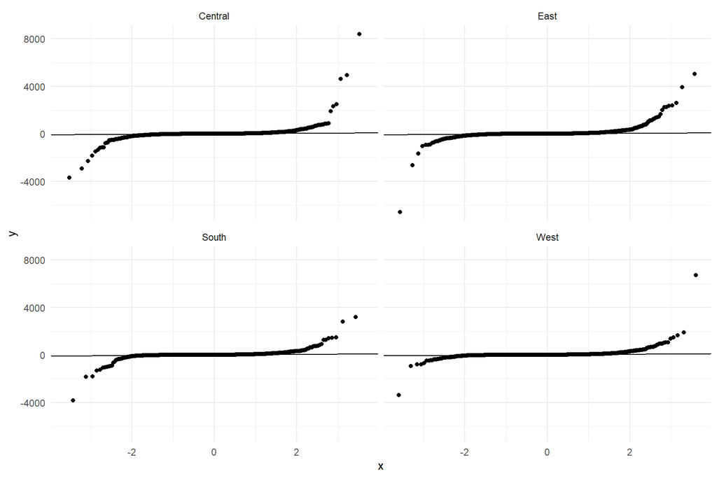

```r
# QQ-plot por Region
ggplot(datos, aes(sample = Profit)) +
  stat_qq() + stat_qq_line() +
  facet_wrap(~ Region) +
  theme_minimal()
```

```r
#Shapiro
set.seed(123)
datos %>%
  group_by(Region) %>%
  summarise(
    p_value = shapiro.test(sample(Profit, min(500, n())))$p.value
  )
```

```
## # A tibble: 4 × 2
##   Region   p_value
##   <fct>      <dbl>
## 1 Central 4.90e-33
## 2 East    1.15e-38
## 3 South   1.24e-39
## 4 West    1.41e-42
```

```r
# Prueba de Levene (homogeneidad de varianzas)
leveneTest(Profit ~ Region, data = datos)
```

```
## Levene's Test for Homogeneity of Variance (center = median)
##         Df F value    Pr(>F)
## group    3  5.5786 0.0008059 ***
##       9990
## ---
## Signif. codes:  0 '***' 0.001 '**' 0.01 '*' 0.05 '.' 0.1 ' ' 1
```

#### 5. Planteamiento de la hipótesis

H0: Las medias de Profit son iguales entre las 4 regiones. H1: Al menos una media difiere de las demás. Por convención científica significa que acepta hasta un 5% de riesgo de rechazar H0 siendo verdadera.

#### 6. Prueba ANOVA

```r
anova_resultado <- aov(Profit ~ Region, data = datos)
summary(anova_resultado)
```

```
##               Df    Sum Sq Mean Sq F value Pr(>F)
## Region         3    431537  143846   2.622 0.0489 *
## Residuals   9990 547962299   54851
## ---
## Signif. codes:  0 '***' 0.001 '**' 0.01 '*' 0.05 '.' 0.1 ' ' 1
```

Como el valor p es menor que 0.05, se rechaza la hipotesis nula.

#### 7. Comparaciones múltiples

```r
TukeyHSD(anova_resultado)
```

```
##   Tukey multiple comparisons of means
##     95% family-wise confidence level
##
## Fit: aov(formula = Profit ~ Region, data = datos)
##
## $Region
##                    diff         lwr      upr     p adj
## East-Central  15.043099  -1.7808459 31.86704 0.0986433
## South-Central 11.764964  -7.7140259 31.24395 0.4064931
## West-Central  16.756323   0.3565617 33.15608 0.0430362
## South-East    -3.278135 -22.0049635 15.44869 0.9696845
## West-East      1.713224 -13.7856543 17.21210 0.9920144
## West-South     4.991359 -13.3553351 23.33805 0.8974796
```

- East-Central: p = 0.0986433 -> no hay diferencia significativa.
- South-Central: p = 0.4064931 -> no hay diferencia significativa.
- West-Central: p = 0.0430362 -> sí hay diferencia significativa.
- South-East: p = 0.9696845 -> no hay diferencia significativa.
- West-East: p = 0.9920144 -> no hay diferencia significativa.
- West-South: p = 0.8974796 -> no hay diferencia significativa.

#### 8. Visualización

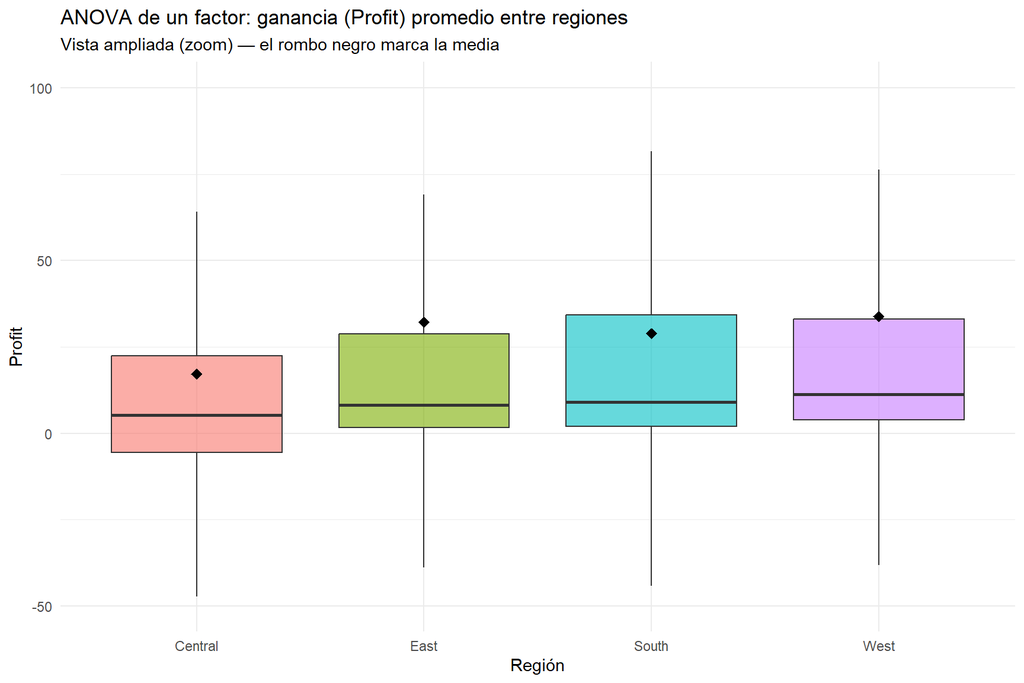

```r
ggplot(datos, aes(x = Region, y = Profit, fill = Region)) +
  geom_boxplot(alpha = 0.6, outlier.shape = NA) +  # oculta los outliers extremos
  stat_summary(fun = mean, geom = "point", shape = 18, size = 3, color = "black") +
  coord_cartesian(ylim = c(-50, 100)) +  # hace "zoom" sin eliminar datos reales
  labs(
    title = "ANOVA de un factor: ganancia (Profit) promedio entre regiones",
    subtitle = "Vista ampliada (zoom) — el rombo negro marca la media",
    x = "Región", y = "Profit"
  ) +
  theme_minimal() +
  theme(legend.position = "none")
```

### MANOVA

#### 1. Librerías

```r
library(tidyverse)
library(biotools)
library(car)
```

#### 2. Cargar los datos

```r
datos2 <- Sample_Superstore
```

#### 2.1 Pasamos las variables Category y Segment en factores

```r
datos2$Category <- factor(datos2$Category)
datos2$Segment  <- factor(datos2$Segment)

str(datos2)
```

```
## 'data.frame':    9994 obs. of  21 variables:
##  $ Row.ID       : int  1 2 3 4 5 6 7 8 9 10 ...
##  $ Order.ID     : chr  "CA-2016-152156" "CA-2016-152156" "CA-2016-138688" "US-2015-108966" ...
##  $ Order.Date   : chr  "11/8/2016" "11/8/2016" "6/12/2016" "10/11/2015" ...
##  $ Ship.Date    : chr  "11/11/2016" "11/11/2016" "6/16/2016" "10/18/2015" ...
##  $ Ship.Mode    : chr  "Second Class" "Second Class" "Second Class" "Standard Class" ...
##  $ Customer.ID  : chr  "CG-12520" "CG-12520" "DV-13045" "SO-20335" ...
##  $ Customer.Name: chr  "Claire Gute" "Claire Gute" "Darrin Van Huff" "Sean O'Donnell" ...
##  $ Segment      : Factor w/ 3 levels "Consumer","Corporate",..: 1 1 2 1 1 1 1 1 1 1 ...
##  $ Country      : chr  "United States" "United States" "United States" "United States" ...
##  $ City         : chr  "Henderson" "Henderson" "Los Angeles" "Fort Lauderdale" ...
##  $ State        : chr  "Kentucky" "Kentucky" "California" "Florida" ...
##  $ Postal.Code  : int  42420 42420 90036 33311 33311 90032 90032 90032 90032 90032 ...
##  $ Region       : chr  "South" "South" "West" "South" ...
##  $ Product.ID   : chr  "FUR-BO-10001798" "FUR-CH-10000454" "OFF-LA-10000240" "FUR-TA-10000577" ...
##  $ Category     : Factor w/ 3 levels "Furniture","Office Supplies",..: 1 1 2 1 2 1 2 3 2 2 ...
##  $ Sub.Category : chr  "Bookcases" "Chairs" "Labels" "Tables" ...
##  $ Product.Name : chr  "Bush Somerset Collection Bookcase" "Hon Deluxe Fabric Upholstered Stacking Chairs, Rounded Back" "Self-Adhesive Address Labels for Typewriters by Universal" "Bretford CR4500 Series Slim Rectangular Table" ...
##  $ Sales        : num  262 731.9 14.6 957.6 22.4 ...
##  $ Quantity     : int  2 3 2 5 2 7 4 6 3 5 ...
##  $ Discount     : num  0 0 0 0.45 0.2 0 0 0.2 0.2 0 ...
##  $ Profit       : num  41.91 219.58 6.87 -383.03 2.52 ...
```

```r
head(datos2)
```

```
##   Row.ID       Order.ID Order.Date  Ship.Date      Ship.Mode Customer.ID
## 1      1 CA-2016-152156  11/8/2016 11/11/2016   Second Class    CG-12520
## 2      2 CA-2016-152156  11/8/2016 11/11/2016   Second Class    CG-12520
## 3      3 CA-2016-138688  6/12/2016  6/16/2016   Second Class    DV-13045
## 4      4 US-2015-108966 10/11/2015 10/18/2015 Standard Class    SO-20335
## 5      5 US-2015-108966 10/11/2015 10/18/2015 Standard Class    SO-20335
## 6      6 CA-2014-115812   6/9/2014  6/14/2014 Standard Class    BH-11710
##     Customer.Name   Segment       Country            City      State
## 1     Claire Gute  Consumer United States       Henderson   Kentucky
## 2     Claire Gute  Consumer United States       Henderson   Kentucky
## 3 Darrin Van Huff Corporate United States     Los Angeles California
## 4  Sean O'Donnell  Consumer United States Fort Lauderdale    Florida
## 5  Sean O'Donnell  Consumer United States Fort Lauderdale    Florida
## 6 Brosina Hoffman  Consumer United States     Los Angeles California
##   Postal.Code Region      Product.ID        Category Sub.Category
```

[output cut: 20 more lines]

```r
table(datos2$Category, datos2$Segment)
```

```
##
##                   Consumer Corporate Home Office
##   Furniture           1113       646         362
##   Office Supplies     3127      1820        1079
##   Technology           951       554         342
```

#### 3. Análisis exploratorio

```r
datos2 %>%
  group_by(Category, Segment) %>%
  summarise(media_sales = mean(Sales),
            media_profit = mean(Profit),
            .groups = "drop")
```

```
## # A tibble: 9 × 4
##   Category        Segment     media_sales media_profit
##   <fct>           <fct>             <dbl>        <dbl>
## 1 Furniture       Consumer           351.         6.28
## 2 Furniture       Corporate          355.        11.7
## 3 Furniture       Home Office        337.        10.7
## 4 Office Supplies Consumer           116.        18.0
## 5 Office Supplies Corporate          127.        22.1
## 6 Office Supplies Home Office        115.        24.0
## 7 Technology      Consumer           427.        74.4
## 8 Technology      Corporate          445.        79.7
## 9 Technology      Home Office        536.        89.2
```

```r
cor(datos2$Sales, datos2$Profit) #Correlacion
```

```
## [1] 0.4790643
```

#### 4. Supuestos

#### 4.1 Vamos a evaluar la normalidad

Usamos Henze-Zirkler.

```r
henze_zirkler <- function(X) {
  X <- as.matrix(X)
  n <- nrow(X); p <- ncol(X)
  S <- cov(X); Sinv <- solve(S)
  Xc <- scale(X, center = TRUE, scale = FALSE)

  G  <- Xc %*% Sinv %*% t(Xc)
  Di <- diag(G)
  Dij <- outer(Di, Di, "+") - 2 * G
  Dij[Dij < 0] <- 0

  beta <- (1 / sqrt(2)) * ((n * (2 * p + 1) / 4)^(1 / (p + 4)))
  b2   <- beta^2
  t1 <- sum(exp(-b2 / 2 * Dij)) / n^2
  t2 <- -2 * (1 + b2)^(-p/2) * sum(exp(-b2 / (2 * (1 + b2)) * Di)) / n
  t3 <- (1 + 2 * b2)^(-p/2)
  HZ <- n * (t1 + t2 + t3)
  wb  <- (1 + b2) * (1 + 3 * b2); a <- 1 + 2 * b2
  mu  <- 1 - a^(-p/2) * (1 + p * b2 / a + p * (p + 2) * b2^2 / (2 * a^2))
  si2 <- 2 * (1 + 4 * b2)^(-p/2) +
    2 * a^(-p) * (1 + 2 * p * b2^2 / a^2 + 3 * p * (p + 2) * b2^4 / (4 * a^4)) -
    4 * wb^(-p/2) * (1 + 3 * p * b2^2 / (2 * wb) + p * (p + 2) * b2^4 / (2 * wb^2))
  pmu <- log(sqrt(mu^4 / (si2 + mu^2)))
  psi <- sqrt(log((si2 + mu^2) / mu^2))
  pval <- 1 - pnorm((log(HZ) - pmu) / psi)
  cat("Prueba de Henze-Zirkler (normalidad multivariada)\n")
  cat(sprintf("  Estadistico HZ : %.4f\n", HZ))
  cat(sprintf("  Valor p        : %.4f\n", pval))
  cat(sprintf("  Normalidad MVN : %s\n", ifelse(pval > 0.05, "SI (p > 0.05)", "NO (p <= 0.05)")))
  invisible(list(HZ = HZ, p.value = pval, MVN = pval > 0.05))
}

vd <- datos2[, c("Sales", "Profit")]
henze_zirkler(vd)
```

```
## Prueba de Henze-Zirkler (normalidad multivariada)
##   Estadistico HZ : 4426.7026
##   Valor p        : 0.0000
##   Normalidad MVN : NO (p <= 0.05)
```

#### 4.2 Normalidad univariada Shapiro-Wilk

```r
mod_lm <- lm(cbind(Sales, Profit) ~ Category * Segment,
             data = datos2)
res <- residuals(mod_lm) #Residuales del modelo

set.seed(123)
shapiro.test(sample(res[, "Sales"], 5000))    #espero p>0.05
```

```
##
##  Shapiro-Wilk normality test
##
## data:  sample(res[, "Sales"], 5000)
## W = 0.3573, p-value < 2.2e-16
```

```r
shapiro.test(sample(res[, "Profit"], 5000))   #espero p>0.05
```

```
##
##  Shapiro-Wilk normality test
##
## data:  sample(res[, "Profit"], 5000)
## W = 0.27522, p-value < 2.2e-16
```

#### 4.3 Homogeneidad de matrices de covarianza

```r
biotools::boxM(datos2[, c("Sales", "Profit")],
               interaction(datos2$Category, datos2$Segment))
```

```
##
##  Box's M-test for Homogeneity of Covariance Matrices
##
## data:  datos2[, c("Sales", "Profit")]
## Chi-Sq (approx.) = 9647.5, df = 24, p-value < 2.2e-16
```

#### 4.4 Homogeneidad de varianzas univariadas

```r
leveneTest(Sales ~ Category * Segment, data = datos2)
```

```
## Levene's Test for Homogeneity of Variance (center = median)
##         Df F value    Pr(>F)
## group    8  47.258 < 2.2e-16 ***
##       9985
## ---
## Signif. codes:  0 '***' 0.001 '**' 0.01 '*' 0.05 '.' 0.1 ' ' 1
```

```r
leveneTest(Profit ~ Category * Segment, data = datos2)
```

```
## Levene's Test for Homogeneity of Variance (center = median)
##         Df F value    Pr(>F)
## group    8  21.085 < 2.2e-16 ***
##       9985
## ---
## Signif. codes:  0 '***' 0.001 '**' 0.01 '*' 0.05 '.' 0.1 ' ' 1
```

#### 5. Planteo de Hipótesis

Sea mu = (mu_Sales, mu_Profit) el vector de medias.

**Efecto CATEGORY:**

- H0: mu_Furniture = mu_OfficeSupplies = mu_Technology
- H1: al menos un vector de medias difiere entre categorías de producto

**Efecto SEGMENT:**

- H0: mu_Consumer = mu_Corporate = mu_HomeOffice
- H1: al menos un vector de medias difiere entre segmentos de cliente

**INTERACCION Category x Segment:**

- H0: el efecto del segmento es el mismo para las tres categorías de producto (sin interacción)
- H1: el efecto del segmento depende de la categoría de producto

#### 6. Ajuste de modelo MANOVA

```r
modelo <- manova(cbind(Sales, Profit) ~ Category * Segment,
                 data = datos2)
summary(modelo, test = "Pillai")
```

```
##                    Df   Pillai approx F num Df den Df Pr(>F)
## Category            2 0.061526  158.458      4  19970 <2e-16 ***
## Segment             2 0.000194    0.483      4  19970 0.7480
## Category:Segment    4 0.000832    1.039      8  19970 0.4036
## Residuals        9985
## ---
## Signif. codes:  0 '***' 0.001 '**' 0.01 '*' 0.05 '.' 0.1 ' ' 1
```

#### 7. ANOVA univariado de seguimiento

```r
summary.aov(modelo)
```

```
##  Response Sales :
##                    Df     Sum Sq  Mean Sq  F value Pr(>F)
## Category            2  195881745 97940872 265.5638 <2e-16 ***
## Segment             2     453622   226811   0.6150 0.5407
## Category:Segment    4    2786415   696604   1.8888 0.1094
## Residuals        9985 3682503730   368804
## ---
## Signif. codes:  0 '***' 0.001 '**' 0.01 '*' 0.05 '.' 0.1 ' ' 1
##
##  Response Profit :
##                    Df    Sum Sq Mean Sq F value Pr(>F)
## Category            2   5898009 2949004 54.2891 <2e-16 ***
## Segment             2     87244   43622  0.8030 0.4480
## Category:Segment    4     19149    4787  0.0881 0.9862
## Residuals        9985 542389434   54320
## ---
## Signif. codes:  0 '***' 0.001 '**' 0.01 '*' 0.05 '.' 0.1 ' ' 1
```

#### 8. Visualización

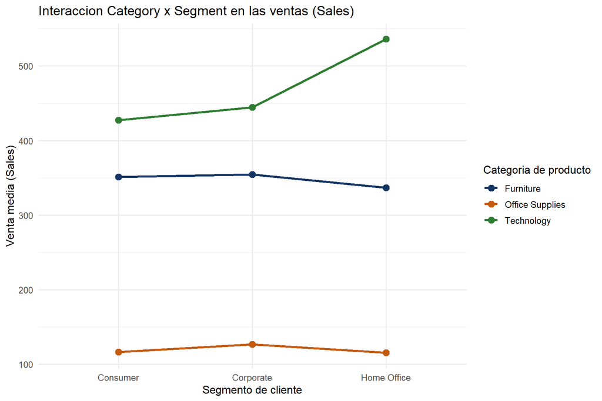

```r
medias <- datos2 %>%
  group_by(Category, Segment) %>%
  summarise(media_sales = mean(Sales), .groups = "drop")

ggplot(medias, aes(x = Segment, y = media_sales,
                   color = Category, group = Category)) +
  geom_line(linewidth = 1.1) +
  geom_point(size = 3) +
  labs(title = "Interaccion Category x Segment en las ventas (Sales)",
       x = "Segmento de cliente", y = "Venta media (Sales)",
       color = "Categoria de producto") +
  scale_color_manual(values = c("#153664", "#C55A11", "#2E7D32")) +
  theme_minimal(base_size = 12)
```